# Log Transformation in Regression

- 같은 내용이 [여기](https://danbi-ncsoft.github.io/study/2018/08/07/logwithlevel.html)에도 게재되었습니다.

## Intro

회귀분석을 하다보면 여러가지 이유로 변환(transformation)을 하게 된다. 가장 흔하게 하는 변환은 log 변환이다. 회귀분석의 좌변(종속변수)와 우변(독립변수)를 각기 log로 변환한다고 하면, 변환 유무에 따라서 네 가지 조합이 가능하다.

|  | level | log |
| --- | --- | --- |
| **level** | $y_i = \alpha + \beta x_i + \varepsilon_i$ | $y_i = \alpha + \beta \log x_i + \varepsilon_i$ |
| **log** | $\log y_i = \alpha + \beta x_i + \varepsilon_i$ | $\log y_i = \alpha + \beta \log x_i + \varepsilon_i$ |

level-level의 조합에서 $\beta$는 $x$의 한 단위 변화에 대한 $y$의 변화 단위를 측정한다. 이하에서는 오해의 소지가 없는 이상 $i$ 인덱스 와 $\varepsilon_i$은 생략하도록 하자.

## log-level model

살짝 복잡하지만 log-level 모형부터 시작해보자. 계산 과정을 이해하는 데 도움이 된다.

$$\log y = \alpha + \beta x$$

- $y$에 붙은 로그를 제거한다. $y = e^{\alpha + \beta x}$
- $x$가 $\Delta x$ 만큼 변하면 그에 상응하여 $y$가 $\Delta y$ 만큼 변한다고 하자. $y + \Delta y = e^{\alpha + \beta (x + \Delta x)} = e^{\alpha + \beta x} e^{\beta \Delta x}= y (e^{\beta \Delta x})$
- 양변을 $y$로 나눈다. $\frac{y + \Delta y}{y} = 1 + \frac{\Delta y}{y} = e^{\beta \Delta x}$
- 종속변수에 log를 취했다면 $x$의 $\Delta x$ 증가에 대한 $y$의 % 변화율은 위와 같이 측정할 수 있다. $100 \times \frac{\Delta y}{y} = (e^{\beta \Delta x} -1) \times 100$
- 근사치로 해석해보자. $\beta \Delta x$ 값이 크지 않다면 (대략 0.1이하), $e^{\beta \Delta x} \approx 1 + \beta \Delta x$에 따라서 대략 $(\beta \Delta x \times 100)$ % 변화로 간주해도 무방하다.
- 같은 취지로 식의 양변을 편미분해서 동일한 결과를 도출할 수 있다.
  $$\dfrac{d{\,}y / d{\,}x }{y} = \dfrac{d{\,}y / y }{d{\,}x} = \beta$$
- $\dfrac{d{\,}y / y }{d{\,}x}$는 $x$가 몹시 미세하게(infinitesimal) 변화할 때 $d{\,}y / y$의 ‘순간’(instantaneous) 변화비율을 나타낸다. 만일 이를 %로 표시하고 싶다면, $\beta \times 100$이 된다.

## level-log model

$$y = \alpha + \beta \log x$$

- 앞서와 마찬가지로 $\Delta x$, $\Delta y$를 적어보자. $y + \Delta y = \alpha + \beta \log (x + \Delta x)$
- 양변에서 $y$를 빼주면 아래와 같이 전개된다. $\Delta y = \beta (\log (x + \Delta x) - \log x) = \beta \log (1+\frac{\Delta x}{x})$
- 만일 $\frac{\Delta x}{x}$의 값이 작다면, $\log(1+\frac{\Delta x}{x}) \approx \frac{\Delta x}{x}$를 사용할 수 있다. $\frac{\Delta x}{x}$를 %로 표현하고 싶다면 100을 곱하면 된다. 따라서 $\Delta y \approx \frac{\beta}{100} (100 \times \Delta x / x)$ 라고 볼 수 있다.
- 같은 결과를 편미분을 통해 도출할 수 있다. 양변을 $x$에 대해서 미분하면
  $$dy = \beta \dfrac{dx}{x}$$

## log-log model

$$\log y = \alpha + \beta \log x$$

정확한 변화를 계산하는 것은 위의 두 과정을 합친 것과 비슷하니 각자 연습해보기 바란다! 혹시 어렵다면 아래 부록을 참고하기 바란다. 이 문제도 역시 편미분으로 접근하면 조금 이해가 쉽다. 모델에서 $\beta$는 $\log y$를 $\log x$에 대해서 편미분한 값과 같다. 즉,

$$\beta = \dfrac{d{\,}{\log y}}{d{\,}\log x} = \dfrac{(dy / y) \times 100}{(dx / x) \times 100}$$

이때 $\beta$는 $x$의 미세한 % 변화율에 대한 $y$의 % 변화율을 측정한다. 둘 다 % 변화로 표현되었기 때문에 단위에서 자유롭다. 경제학에서 흔히 “순간 탄력성”이라고 부르는 값이다. 즉, 가격의 미세한 $x$ % 변화에 대한 수요의 변화율을 측정한다. 경제학에서 log-log 변환이 유달리 많이 사용되는 이유는 이렇듯 경제적인 해석이 쉽기 때문이다.

### (부록) log-log 계산

$$\begin{align}
y + \Delta y &= e^{\alpha + \beta \log (x + \Delta x)} \\
1 + \frac{\Delta y}{y} &= e^{\beta \log (1 + \frac{\Delta x}{x})}
\end{align}$$

양변에 로그를 취하면, $\log (1+\frac{\Delta y}{y} ) = \beta \log (1+\frac{\Delta x}{x})$

만일 $\frac{\Delta y}{y}$, $\frac{\Delta x}{x}$가 충분히 작다면, $\frac{\Delta y}{y} \approx \beta \frac{\Delta x}{x}$

## Case in action

변환을 이용하면 비선형적인 함수 관계를 선형으로 바꿔 다룰 수 있다. 그 대신 계수 해석에서는 몹시 조심해야 한다. 우선, %로 간편하게 근사치로 해석을 하려면 각 변화량이 크면 안된다. 근사치의 오차가 너무 큰 상황에서 근사치를 쓰면 안되는 것이다. 특히 주의해야 할 것이 더미변수다. 만일 설명 변수에 더미 변수가 들어 있고, 종속 변수가 로그 변환되어 있다면, 계수 값을 그대로 log-level 모델에 따라서 $100 \times \beta$로 해석하면 곤란하다. 더미 변수는 질적 변수이고, 변수의 차이는 측정할 수 없다. 이 경우는 $e^{\beta} -1$을 변화율로 따져야 한다.

### log-level 모형에서 더미 변수 해석

$\log(\text{write}) = \beta_0 + \beta_1 * \text{female} + \beta_2 * \text{read} + \beta_3 * \text{math}$

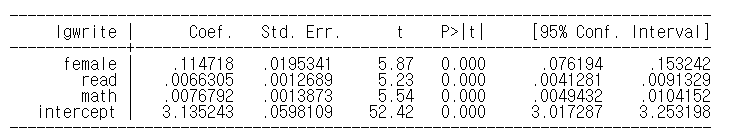

### level-log 모형에서 변수 해석

$\text{write} = \beta_0 + \beta_1 * \text{female} + \beta_2 * \log \text{read} + \beta_3 * \log \text{math}$

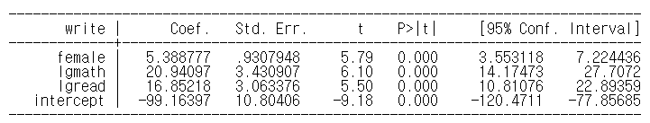

$\log \text{read}$의 계수는 어떻게 해석해야 할까? read 값은 연속 값이므로 1%의 작은 값을 취하는 것이 가능하다. 따라서 근사 값으로 해석해도 무방하다. 앞서 보았 듯 read 값의 1% 증가는 $\beta \times 0.01$ 만큼의 효과를 종속 변수에 준다. 종속 변수는 level이라는 점을 확인해두자. 즉,read 값이 1% 증가하면 쓰기 점수가 약 0.17 만큼의 증가한다.

### log-log 모형에서 변수 해석

$\log \text{write} = \beta_0 + \beta_1 * \text{female} + \beta_2 * \log \text{math} +\beta_3 *\text{read}$

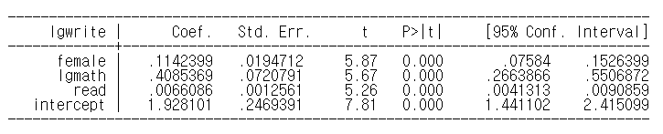

$\beta_2$는 어떻게 해석해야 할까? 근사 값로 해석하면 된다. 수학 점수 1% 상승은 쓰기 점수 0.4% 상승을 가져온다.

## Reference

- http://kenbenoit.net/assets/courses/ME104/logmodels2.pdf
- [UCLA 대학 통계센터](https://stats.idre.ucla.edu/other/mult-pkg/faq/general/faqhow-do-i-interpret-a-regression-model-when-some-variables-are-log-transformed)